# Exploring data graphically

### Learning Objectives

- Learn how to plot with matplotlib
- Set universal plot settings.
- Produce scatter plots, line plots, and histograms using seaborn and matplotlib.
- Understand how to graphically explore relationships between variables.
- Apply grids for faceting in seaborn.
- Use seaborn grids with matplotlib functions

### Lesson outline

- Data visualization with matplotlib and seaborn (10 min)
  - Intro to plotting with matplotlib
  - Visualizing one quantitative variable with multiple categorical variables (50 min)
  - Visualizing the relationship of two quantitative variable with multiple categorical variables (40min)

## Short review from yesterday

Do you remember how to:

1 - Read in the data from the csv file from yesterday?

```python
import pandas as pd

world_data = pd.read_csv('https://raw.githubusercontent.com/UofTCoders/2018-09-10-utoronto/gh-pages/data/world-data-gapminder.csv')

# If saved locally yesterday:
# surveys = pd.read_csv("world_data.csv")
```

2 - How to select only the columns 'country' and 'year' from the dataframe?

```python
world_data[['country', 'year']].head() #head just to limit output
```

|  | country | year |
| --- | --- | --- |
| 0 | Afghanistan | 1800 |
| 1 | Afghanistan | 1801 |
| 2 | Afghanistan | 1802 |
| 3 | Afghanistan | 1803 |
| 4 | Afghanistan | 1804 |

3 - How to select a few rows together with the columns above?

```python
world_data.loc[[1, 13, 24], ['country', 'year']]
```

|  | country | year |
| --- | --- | --- |
| 1 | Afghanistan | 1801 |
| 13 | Afghanistan | 1813 |
| 24 | Afghanistan | 1824 |

4 - How to select only data from year 1995?

```python
world_data.loc[world_data['year'] == 1995]
```

|  | country | year | population | region | sub_region | income_group | life_expectancy | income | children_per_woman | child_mortality | pop_density | co2_per_capita | years_in_school_men | years_in_school_women |
| --- | --- | --- | --- | --- | --- | --- | --- | --- | --- | --- | --- | --- | --- | --- |
| 195 | Afghanistan | 1995 | 17100000 | Asia | Southern Asia | Low | 51.1 | 881 | 7.61 | 150.0 | 26.20 | 0.0727 | 2.56 | 0.49 |
| 414 | Albania | 1995 | 3110000 | Europe | Southern Europe | Upper middle | 74.1 | 4130 | 2.59 | 32.9 | 113.00 | 0.6720 | 9.31 | 9.07 |
| 633 | Algeria | 1995 | 28900000 | Africa | Northern Africa | Upper middle | 72.3 | 9300 | 3.45 | 43.3 | 12.10 | 3.3000 | 5.67 | 4.84 |
| 852 | Angola | 1995 | 14300000 | Africa | Sub-Saharan Africa | Lower middle | 52.0 | 2970 | 6.92 | 223.0 | 11.40 | 0.7690 | 4.89 | 3.05 |
| 1071 | Antigua and Barbuda | 1995 | 73600 | Americas | Latin America and the Caribbean | High | 74.4 | 16500 | 2.21 | 19.5 | 167.00 | 3.7400 | 10.50 | 11.40 |
| 1290 | Argentina | 1995 | 35000000 | Americas | Latin America and the Caribbean | High | 73.1 | 13900 | 2.76 | 24.3 | 12.80 | 3.6600 | 9.53 | 10.00 |
| 1509 | Armenia | 1995 | 3220000 | Asia | Western Asia | Upper middle | 69.3 | 2170 | 1.80 | 38.7 | 113.00 | 1.0600 | 10.10 | 10.20 |
| 1728 | Australia | 1995 | 18100000 | Oceania | Australia and New Zealand | High | 78.3 | 30400 | 1.82 | 7.0 | 2.35 | 15.6000 | 11.80 | 11.80 |
| 1947 | Austria | 1995 | 7990000 | Europe | Western Europe | High | 76.7 | 33700 | 1.42 | 6.8 | 97.00 | 7.4800 | 10.90 | 10.50 |
| 2166 | Azerbaijan | 1995 | 7780000 | Asia | Western Asia | Upper middle | 64.9 | 3320 | 2.58 | 94.1 | 94.10 | 4.2900 | 10.70 | 10.30 |
| 2385 | Bahamas | 1995 | 280000 | Americas | Latin America and the Caribbean | High | 70.6 | 22100 | 2.51 | 18.7 | 28.00 | 6.0100 | 10.00 | 10.40 |
| 2604 | Bahrain | 1995 | 564000 | Asia | Western Asia | High | 70.3 | 43500 | 3.10 | 18.1 | 742.00 | 26.3000 | 7.41 | 7.54 |
| 2823 | Bangladesh | 1995 | 119000000 | Asia | Southern Asia | Lower middle | 61.7 | 1440 | 3.73 | 114.0 | 912.00 | 0.1920 | 4.34 | 2.75 |
| 3042 | Barbados | 1995 | 265000 | Americas | Latin America and the Caribbean | High | 73.7 | 12400 | 1.73 | 14.7 | 616.00 | 3.1300 | 7.53 | 7.82 |
| 3261 | Belarus | 1995 | 10100000 | Europe | Eastern Europe | Upper middle | 68.3 | 5450 | 1.47 | 15.7 | 50.00 | 5.9900 | 11.10 | 11.60 |
| 3480 | Belgium | 1995 | 10200000 | Europe | Western Europe | High | 76.9 | 32700 | 1.61 | 7.6 | 336.00 | 11.0000 | 11.40 | 11.60 |
| 3699 | Belize | 1995 | 207000 | Americas | Latin America and the Caribbean | Upper middle | 70.7 | 6210 | 4.11 | 29.5 | 9.07 | 1.8200 | 7.17 | 6.63 |
| 3918 | Benin | 1995 | 5910000 | Africa | Sub-Saharan Africa | Low | 56.5 | 1520 | 6.36 | 158.0 | 52.40 | 0.2250 | 3.62 | 1.48 |
| 4137 | Bhutan | 1995 | 515000 | Asia | Southern Asia | Lower middle | 62.9 | 2900 | 4.60 | 101.0 | 13.50 | 0.4840 | 4.41 | 1.78 |
| 4356 | Bolivia | 1995 | 7570000 | Americas | Latin America and the Caribbean | Lower middle | 64.3 | 4110 | 4.58 | 101.0 | 6.98 | 1.3000 | 8.11 | 6.64 |
| 4575 | Bosnia and Herzegovina | 1995 | 3840000 | Europe | Southern Europe | Upper middle | 68.9 | 1830 | 1.71 | 14.2 | 75.40 | 0.8920 | 8.46 | 7.82 |
| 4794 | Botswana | 1995 | 1570000 | Africa | Sub-Saharan Africa | Upper middle | 56.4 | 8900 | 3.95 | 71.6 | 2.77 | 1.9400 | 5.11 | 5.59 |
| 5013 | Brazil | 1995 | 162000000 | Americas | Latin America and the Caribbean | Upper middle | 69.7 | 11100 | 2.50 | 49.1 | 19.40 | 1.5900 | 5.99 | 6.46 |
| 5232 | Bulgaria | 1995 | 8380000 | Europe | Eastern Europe | Upper middle | 71.0 | 8450 | 1.34 | 19.2 | 77.20 | 6.9200 | 10.70 | 11.20 |
| 5451 | Burkina Faso | 1995 | 10100000 | Africa | Sub-Saharan Africa | Low | 50.7 | 869 | 6.84 | 195.0 | 36.90 | 0.0621 | 1.86 | 0.91 |
| 5670 | Burundi | 1995 | 5960000 | Africa | Sub-Saharan Africa | Low | 47.0 | 870 | 7.29 | 169.0 | 232.00 | 0.0400 | 3.45 | 2.31 |
| 5889 | Cambodia | 1995 | 10700000 | Asia | South-eastern Asia | Lower middle | 58.2 | 1100 | 4.69 | 120.0 | 60.40 | 0.1460 | 4.97 | 3.36 |
| 6108 | Cameroon | 1995 | 13500000 | Africa | Sub-Saharan Africa | Lower middle | 56.5 | 2260 | 5.98 | 166.0 | 28.50 | 0.3140 | 6.45 | 4.36 |
| 6327 | Canada | 1995 | 29300000 | Americas | Northern America | High | 78.0 | 32200 | 1.64 | 6.9 | 3.23 | 15.9000 | 13.60 | 13.60 |
| 6546 | Central African Republic | 1995 | 3350000 | Africa | Sub-Saharan Africa | Low | 46.2 | 858 | 5.62 | 175.0 | 5.38 | 0.0700 | 4.92 | 2.43 |
| ... | ... | ... | ... | ... | ... | ... | ... | ... | ... | ... | ... | ... | ... | ... |
| 32607 | Sri Lanka | 1995 | 18200000 | Asia | Southern Asia | Lower middle | 72.2 | 4510 | 2.29 | 20.3 | 291.00 | 0.3240 | 8.57 | 8.44 |
| 32826 | Sudan | 1995 | 24100000 | Africa | Northern Africa | Lower middle | 60.4 | 1960 | 5.83 | 120.0 | 13.70 | 0.1780 | 5.70 | 3.37 |
| 33045 | Suriname | 1995 | 444000 | Americas | Latin America and the Caribbean | Upper middle | 70.3 | 9620 | 3.01 | 39.7 | 2.84 | 4.6500 | 7.25 | 6.89 |
| 33264 | Swaziland | 1995 | 961000 | Africa | Sub-Saharan Africa | Lower middle | 59.4 | 5610 | 4.80 | 83.7 | 55.90 | 0.4730 | 6.94 | 6.80 |
| 33483 | Sweden | 1995 | 8840000 | Europe | Northern Europe | High | 78.8 | 31100 | 1.73 | 4.8 | 21.50 | 6.2400 | 12.20 | 12.40 |
| 33702 | Switzerland | 1995 | 7020000 | Europe | Western Europe | High | 78.5 | 45900 | 1.52 | 6.4 | 178.00 | 5.5900 | 12.20 | 11.40 |
| 33921 | Syria | 1995 | 14300000 | Asia | Western Asia | Low | 72.1 | 4890 | 4.51 | 29.6 | 78.10 | 2.9000 | 7.18 | 5.05 |
| 34140 | Tajikistan | 1995 | 5760000 | Asia | Central Asia | Low | 63.9 | 1270 | 4.59 | 119.0 | 41.20 | 0.4250 | 10.50 | 9.52 |
| 34359 | Tanzania | 1995 | 30000000 | Africa | Sub-Saharan Africa | Low | 52.9 | 1370 | 5.88 | 164.0 | 33.80 | 0.1190 | 5.77 | 4.57 |
| 34578 | Thailand | 1995 | 59500000 | Asia | South-eastern Asia | Upper middle | 70.9 | 9380 | 1.87 | 29.2 | 116.00 | 2.7100 | 7.30 | 6.95 |
| 34797 | Timor-Leste | 1995 | 871000 | Asia | South-eastern Asia | Lower middle | 60.9 | 1560 | 6.38 | 139.0 | 58.60 | NaN | 5.49 | 4.09 |
| 35016 | Togo | 1995 | 4270000 | Africa | Sub-Saharan Africa | Low | 57.2 | 1200 | 5.76 | 134.0 | 78.60 | 0.2230 | 5.03 | 2.32 |
| 35235 | Tonga | 1995 | 96100 | Oceania | Polynesia | Upper middle | 68.4 | 4260 | 4.45 | 18.8 | 133.00 | 0.9920 | 9.61 | 9.49 |
| 35454 | Trinidad and Tobago | 1995 | 1260000 | Americas | Latin America and the Caribbean | High | 69.3 | 12900 | 1.96 | 28.0 | 245.00 | 13.6000 | 9.81 | 10.10 |
| 35673 | Tunisia | 1995 | 9110000 | Africa | Northern Africa | Lower middle | 73.0 | 6130 | 2.61 | 44.7 | 58.70 | 1.7300 | 8.20 | 5.28 |
| 35892 | Turkey | 1995 | 58500000 | Asia | Western Asia | Upper middle | 70.9 | 12300 | 2.76 | 54.8 | 76.00 | 2.9400 | 7.62 | 5.59 |
| 36111 | Turkmenistan | 1995 | 4210000 | Asia | Central Asia | Upper middle | 63.1 | 4600 | 3.51 | 87.5 | 8.95 | 8.0800 | 11.20 | 10.90 |
| 36330 | Uganda | 1995 | 20600000 | Africa | Sub-Saharan Africa | Low | 47.0 | 931 | 7.02 | 171.0 | 103.00 | 0.0457 | 5.72 | 3.69 |
| 36549 | Ukraine | 1995 | 50900000 | Europe | Eastern Europe | Lower middle | 66.6 | 5060 | 1.41 | 20.3 | 87.90 | 8.7600 | 11.20 | 11.50 |
| 36768 | United Arab Emirates | 1995 | 2450000 | Asia | Western Asia | High | 73.5 | 102000 | 3.42 | 13.1 | 29.30 | 28.8000 | 9.00 | 9.20 |
| 36987 | United Kingdom | 1995 | 58000000 | Europe | Northern Europe | High | 76.6 | 28600 | 1.76 | 7.2 | 240.00 | 9.2800 | 12.10 | 12.00 |
| 37206 | United States | 1995 | 266000000 | Americas | Northern America | High | 75.9 | 39500 | 1.98 | 9.5 | 29.00 | 19.3000 | 13.40 | 13.40 |
| 37425 | Uruguay | 1995 | 3220000 | Americas | Latin America and the Caribbean | High | 73.5 | 11500 | 2.40 | 20.8 | 18.40 | 1.4200 | 8.70 | 9.31 |
| 37644 | Uzbekistan | 1995 | 22900000 | Asia | Central Asia | Lower middle | 66.2 | 2240 | 3.53 | 70.5 | 53.70 | 4.5200 | 10.50 | 10.20 |
| 37863 | Vanuatu | 1995 | 168000 | Oceania | Melanesia | Lower middle | 62.3 | 2610 | 4.73 | 30.4 | 13.80 | 0.3920 | 6.70 | 5.86 |
| 38082 | Venezuela | 1995 | 22200000 | Americas | Latin America and the Caribbean | Upper middle | 73.0 | 15300 | 3.08 | 26.2 | 25.20 | 6.0100 | 7.87 | 8.22 |
| 38301 | Vietnam | 1995 | 75200000 | Asia | South-eastern Asia | Lower middle | 69.5 | 2040 | 2.71 | 39.0 | 243.00 | 0.3870 | 7.23 | 6.63 |
| 38520 | Yemen | 1995 | 15300000 | Asia | Western Asia | Low | 60.5 | 3530 | 7.53 | 112.0 | 29.00 | 0.6830 | 4.71 | 0.95 |
| 38739 | Zambia | 1995 | 9140000 | Africa | Sub-Saharan Africa | Lower middle | 46.5 | 2030 | 6.19 | 177.0 | 12.30 | 0.2380 | 6.73 | 5.13 |
| 38958 | Zimbabwe | 1995 | 11300000 | Africa | Sub-Saharan Africa | Low | 53.7 | 2480 | 4.43 | 90.1 | 29.30 | 1.3400 | 8.41 | 6.92 |

178 rows × 14 columns

5 - Select only the rows where the region is Asia or Africa.

```python
world_data.loc[world_data['region'].isin(['Asia', 'Africa'])]
```

|  | country | year | population | region | sub_region | income_group | life_expectancy | income | children_per_woman | child_mortality | pop_density | co2_per_capita | years_in_school_men | years_in_school_women |
| --- | --- | --- | --- | --- | --- | --- | --- | --- | --- | --- | --- | --- | --- | --- |
| 0 | Afghanistan | 1800 | 3280000 | Asia | Southern Asia | Low | 28.2 | 603 | 7.00 | 469.0 | NaN | NaN | NaN | NaN |
| 1 | Afghanistan | 1801 | 3280000 | Asia | Southern Asia | Low | 28.2 | 603 | 7.00 | 469.0 | NaN | NaN | NaN | NaN |
| 2 | Afghanistan | 1802 | 3280000 | Asia | Southern Asia | Low | 28.2 | 603 | 7.00 | 469.0 | NaN | NaN | NaN | NaN |
| 3 | Afghanistan | 1803 | 3280000 | Asia | Southern Asia | Low | 28.2 | 603 | 7.00 | 469.0 | NaN | NaN | NaN | NaN |
| 4 | Afghanistan | 1804 | 3280000 | Asia | Southern Asia | Low | 28.2 | 603 | 7.00 | 469.0 | NaN | NaN | NaN | NaN |
| 5 | Afghanistan | 1805 | 3280000 | Asia | Southern Asia | Low | 28.2 | 603 | 7.00 | 469.0 | NaN | NaN | NaN | NaN |
| 6 | Afghanistan | 1806 | 3280000 | Asia | Southern Asia | Low | 28.1 | 603 | 7.00 | 470.0 | NaN | NaN | NaN | NaN |
| 7 | Afghanistan | 1807 | 3280000 | Asia | Southern Asia | Low | 28.1 | 603 | 7.00 | 470.0 | NaN | NaN | NaN | NaN |
| 8 | Afghanistan | 1808 | 3280000 | Asia | Southern Asia | Low | 28.1 | 603 | 7.00 | 470.0 | NaN | NaN | NaN | NaN |
| 9 | Afghanistan | 1809 | 3280000 | Asia | Southern Asia | Low | 28.1 | 603 | 7.00 | 470.0 | NaN | NaN | NaN | NaN |
| 10 | Afghanistan | 1810 | 3280000 | Asia | Southern Asia | Low | 28.1 | 604 | 7.00 | 470.0 | NaN | NaN | NaN | NaN |
| 11 | Afghanistan | 1811 | 3280000 | Asia | Southern Asia | Low | 28.1 | 604 | 7.00 | 470.0 | NaN | NaN | NaN | NaN |
| 12 | Afghanistan | 1812 | 3280000 | Asia | Southern Asia | Low | 28.1 | 604 | 7.00 | 470.0 | NaN | NaN | NaN | NaN |
| 13 | Afghanistan | 1813 | 3280000 | Asia | Southern Asia | Low | 28.1 | 604 | 7.00 | 470.0 | NaN | NaN | NaN | NaN |
| 14 | Afghanistan | 1814 | 3290000 | Asia | Southern Asia | Low | 28.1 | 604 | 7.00 | 470.0 | NaN | NaN | NaN | NaN |
| 15 | Afghanistan | 1815 | 3290000 | Asia | Southern Asia | Low | 28.1 | 604 | 7.00 | 470.0 | NaN | NaN | NaN | NaN |
| 16 | Afghanistan | 1816 | 3300000 | Asia | Southern Asia | Low | 28.1 | 604 | 7.00 | 471.0 | NaN | NaN | NaN | NaN |
| 17 | Afghanistan | 1817 | 3300000 | Asia | Southern Asia | Low | 28.0 | 604 | 7.00 | 471.0 | NaN | NaN | NaN | NaN |
| 18 | Afghanistan | 1818 | 3310000 | Asia | Southern Asia | Low | 28.0 | 604 | 7.00 | 471.0 | NaN | NaN | NaN | NaN |
| 19 | Afghanistan | 1819 | 3320000 | Asia | Southern Asia | Low | 28.0 | 604 | 7.00 | 471.0 | NaN | NaN | NaN | NaN |
| 20 | Afghanistan | 1820 | 3320000 | Asia | Southern Asia | Low | 28.0 | 604 | 7.00 | 471.0 | NaN | NaN | NaN | NaN |
| 21 | Afghanistan | 1821 | 3330000 | Asia | Southern Asia | Low | 28.0 | 607 | 7.00 | 471.0 | NaN | NaN | NaN | NaN |
| 22 | Afghanistan | 1822 | 3340000 | Asia | Southern Asia | Low | 28.0 | 609 | 7.00 | 471.0 | NaN | NaN | NaN | NaN |
| 23 | Afghanistan | 1823 | 3350000 | Asia | Southern Asia | Low | 28.0 | 611 | 7.00 | 471.0 | NaN | NaN | NaN | NaN |
| 24 | Afghanistan | 1824 | 3360000 | Asia | Southern Asia | Low | 28.0 | 613 | 7.00 | 471.0 | NaN | NaN | NaN | NaN |
| 25 | Afghanistan | 1825 | 3380000 | Asia | Southern Asia | Low | 27.9 | 615 | 7.00 | 471.0 | NaN | NaN | NaN | NaN |
| 26 | Afghanistan | 1826 | 3390000 | Asia | Southern Asia | Low | 27.9 | 617 | 7.00 | 473.0 | NaN | NaN | NaN | NaN |
| 27 | Afghanistan | 1827 | 3400000 | Asia | Southern Asia | Low | 27.9 | 619 | 7.00 | 473.0 | NaN | NaN | NaN | NaN |
| 28 | Afghanistan | 1828 | 3420000 | Asia | Southern Asia | Low | 27.9 | 621 | 7.00 | 473.0 | NaN | NaN | NaN | NaN |
| 29 | Afghanistan | 1829 | 3430000 | Asia | Southern Asia | Low | 27.9 | 623 | 7.00 | 473.0 | NaN | NaN | NaN | NaN |
| ... | ... | ... | ... | ... | ... | ... | ... | ... | ... | ... | ... | ... | ... | ... |
| 38952 | Zimbabwe | 1989 | 9900000 | Africa | Sub-Saharan Africa | Low | 62.7 | 2490 | 5.37 | 73.9 | 25.6 | 1.630 | 7.61 | 6.01 |
| 38953 | Zimbabwe | 1990 | 10200000 | Africa | Sub-Saharan Africa | Low | 61.7 | 2590 | 5.18 | 75.2 | 26.3 | 1.540 | 7.74 | 6.16 |
| 38954 | Zimbabwe | 1991 | 10400000 | Africa | Sub-Saharan Africa | Low | 61.0 | 2670 | 5.00 | 77.4 | 27.0 | 1.530 | 7.88 | 6.31 |
| 38955 | Zimbabwe | 1992 | 10700000 | Africa | Sub-Saharan Africa | Low | 59.4 | 2370 | 4.84 | 80.2 | 27.6 | 1.590 | 8.01 | 6.46 |
| 38956 | Zimbabwe | 1993 | 10900000 | Africa | Sub-Saharan Africa | Low | 57.6 | 2350 | 4.69 | 83.4 | 28.2 | 1.500 | 8.14 | 6.61 |
| 38957 | Zimbabwe | 1994 | 11100000 | Africa | Sub-Saharan Africa | Low | 55.8 | 2520 | 4.56 | 86.8 | 28.7 | 1.600 | 8.28 | 6.76 |
| 38958 | Zimbabwe | 1995 | 11300000 | Africa | Sub-Saharan Africa | Low | 53.7 | 2480 | 4.43 | 90.1 | 29.3 | 1.340 | 8.41 | 6.92 |
| 38959 | Zimbabwe | 1996 | 11500000 | Africa | Sub-Saharan Africa | Low | 52.2 | 2690 | 4.33 | 92.8 | 29.8 | 1.300 | 8.54 | 7.07 |
| 38960 | Zimbabwe | 1997 | 11700000 | Africa | Sub-Saharan Africa | Low | 50.8 | 2710 | 4.24 | 94.7 | 30.3 | 1.230 | 8.67 | 7.23 |
| 38961 | Zimbabwe | 1998 | 11900000 | Africa | Sub-Saharan Africa | Low | 49.1 | 2750 | 4.16 | 95.9 | 30.7 | 1.200 | 8.80 | 7.39 |
| 38962 | Zimbabwe | 1999 | 12100000 | Africa | Sub-Saharan Africa | Low | 47.8 | 2690 | 4.10 | 96.4 | 31.2 | 1.310 | 8.93 | 7.55 |
| 38963 | Zimbabwe | 2000 | 12200000 | Africa | Sub-Saharan Africa | Low | 46.7 | 2570 | 4.06 | 96.8 | 31.6 | 1.140 | 9.07 | 7.71 |
| 38964 | Zimbabwe | 2001 | 12400000 | Africa | Sub-Saharan Africa | Low | 46.2 | 2580 | 4.02 | 97.1 | 32.0 | 1.020 | 9.20 | 7.87 |
| 38965 | Zimbabwe | 2002 | 12500000 | Africa | Sub-Saharan Africa | Low | 45.6 | 2320 | 4.00 | 97.7 | 32.3 | 0.957 | 9.33 | 8.03 |
| 38966 | Zimbabwe | 2003 | 12600000 | Africa | Sub-Saharan Africa | Low | 45.3 | 1910 | 3.99 | 98.2 | 32.7 | 0.843 | 9.47 | 8.20 |
| 38967 | Zimbabwe | 2004 | 12800000 | Africa | Sub-Saharan Africa | Low | 45.1 | 1780 | 3.98 | 99.0 | 33.0 | 0.742 | 9.60 | 8.36 |
| 38968 | Zimbabwe | 2005 | 12900000 | Africa | Sub-Saharan Africa | Low | 45.3 | 1650 | 3.99 | 99.7 | 33.4 | 0.832 | 9.73 | 8.53 |
| 38969 | Zimbabwe | 2006 | 13100000 | Africa | Sub-Saharan Africa | Low | 45.7 | 1580 | 3.99 | 100.0 | 33.9 | 0.796 | 9.87 | 8.69 |
| 38970 | Zimbabwe | 2007 | 13300000 | Africa | Sub-Saharan Africa | Low | 46.4 | 1490 | 4.00 | 100.0 | 34.5 | 0.742 | 10.00 | 8.86 |
| 38971 | Zimbabwe | 2008 | 13600000 | Africa | Sub-Saharan Africa | Low | 46.7 | 1210 | 4.01 | 98.0 | 35.0 | 0.573 | 10.10 | 9.03 |
| 38972 | Zimbabwe | 2009 | 13800000 | Africa | Sub-Saharan Africa | Low | 47.5 | 1290 | 4.02 | 94.9 | 35.7 | 0.406 | 10.30 | 9.19 |
| 38973 | Zimbabwe | 2010 | 14100000 | Africa | Sub-Saharan Africa | Low | 49.6 | 1460 | 4.03 | 89.9 | 36.4 | 0.552 | 10.40 | 9.36 |
| 38974 | Zimbabwe | 2011 | 14400000 | Africa | Sub-Saharan Africa | Low | 51.9 | 1660 | 4.02 | 83.8 | 37.2 | 0.665 | 10.50 | 9.53 |
| 38975 | Zimbabwe | 2012 | 14700000 | Africa | Sub-Saharan Africa | Low | 54.1 | 1850 | 4.00 | 76.0 | 38.0 | 0.530 | 10.70 | 9.70 |
| 38976 | Zimbabwe | 2013 | 15100000 | Africa | Sub-Saharan Africa | Low | 55.6 | 1900 | 3.96 | 70.0 | 38.9 | 0.776 | 10.80 | 9.86 |
| 38977 | Zimbabwe | 2014 | 15400000 | Africa | Sub-Saharan Africa | Low | 57.0 | 1910 | 3.90 | 64.3 | 39.8 | 0.780 | 10.90 | 10.00 |
| 38978 | Zimbabwe | 2015 | 15800000 | Africa | Sub-Saharan Africa | Low | 58.3 | 1890 | 3.84 | 59.9 | 40.8 | NaN | 11.10 | 10.20 |
| 38979 | Zimbabwe | 2016 | 16200000 | Africa | Sub-Saharan Africa | Low | 59.3 | 1860 | 3.76 | 56.4 | 41.7 | NaN | NaN | NaN |
| 38980 | Zimbabwe | 2017 | 16500000 | Africa | Sub-Saharan Africa | Low | 59.8 | 1910 | 3.68 | 56.8 | 42.7 | NaN | NaN | NaN |
| 38981 | Zimbabwe | 2018 | 16900000 | Africa | Sub-Saharan Africa | Low | 60.2 | 1950 | 3.61 | 55.5 | 43.7 | NaN | NaN | NaN |

21681 rows × 14 columns

6 - Calculate the total population in each region

```python
world_data.groupby('region')['population'].sum()
```

```
region
Africa       59192998600
Americas     63837885500
Asia        330133218800
Europe       98766930400
Oceania       2422277600
Name: population, dtype: int64
```

7 - Get the number of countries in each region for the year 2018.

```python
world_data.loc[world_data['year'] == 2018].groupby('region').size()
```

```
region
Africa      52
Americas    31
Asia        47
Europe      39
Oceania      9
dtype: int64
```

## Introduction to plotting

The human visual system is one of the most advanced apparatuses for detecting patterns and it allows for quick exploration of complex visual relationships. Data visualization is therefore a quick, efficient way of unearthing clues to interesting features in the data that can later be investigated in a robust, quantitative manner. Visualizations are also unparalleled in communicating insights drawn from data. For these reasons, it is important to possess the skills to graphically represent the data in a way that is efficient for humans to process.

There are many plotting packages in Python, making it possible to create diverse visualizations such as interactive web graphics, 3D animations, statistical visualizations, and map-based plots. When starting out, it can be helpful to find an example of how a plot looks that you want to create and then copy and modify that code. Examples of plots can be found in many excellent online Python plotting galleries, such as those from [matplotlib](https://matplotlib.org/gallery.html), [seaborn](https://seaborn.pydata.org/examples/), and [the Python graph gallery](https://python-graph-gallery.com/all-charts/).

Our focus will be on two of the most useful packages for creating publication quality visualizations: `matplotlib`, which is a robust, detail-oriented, low level plotting interface, and `seaborn`, which provides high level functions on top of `matplotlib` and allows the plotting calls to be expressed in terms what is being explored in the underlying data rather than what graphical elements to add to the plot. The high-level figures created by `seaborn` can be configured via the `matplotlib` parameters, so learning these packages in tandem is useful.

```python
%matplotlib inline
# Note that this will only need to be done the first time you create a plot in a notebook
# all subsequent plots will show up as expected.
```

To facilitate our understanding of plotting concepts, the initial examples here will not include dataframes, but instead have simple lists holding just a few data points. To create a line plot, the `plot()` function from `matplotlib.pyplot` can be used.

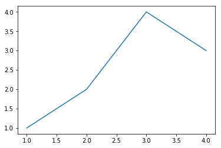

```python
import matplotlib.pyplot as plt

x = [1, 2, 3, 4]
y = [1, 2, 4, 3]
plt.plot(x ,y)
```

Using `plot()` like this is not very explicit and a few things happens "under the hood", e.g. a figure is automatically created and it is assumed that the plot should go into the currently active region of this figure. This gives little control over exactly where to place the plots within a figure and how to make modifications the plot after creating it, e.g. adding a title or labeling the axes.

To facilitate modifications to the plot, it is recommended to use the object oriented plotting interface in `matplotlib`, where an empty figure and at least one axes object is explicitly created before a plot is added to it. This figure and its axes objects are assigned to variable names which are then used for plotting. In `matplotlib`, an axes object refers to what you would often call a subplot colloquially and it is named "axes" because it consists of an x-axis and a y-axis by default.

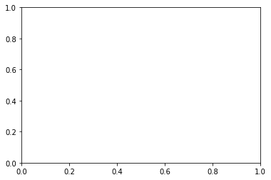

```python
fig, ax = plt.subplots()
```

Calling `subplots()` returns two objects, the figure and its axes object. Plots can be added to the axes object of the figure by using the name we assigned to the returned axes object (`ax` by convention).

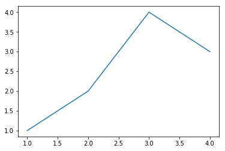

```python
fig, ax = plt.subplots()
ax.plot(x, y)
```

To create a scatter plot, use `scatter()` instead of `plot()`.

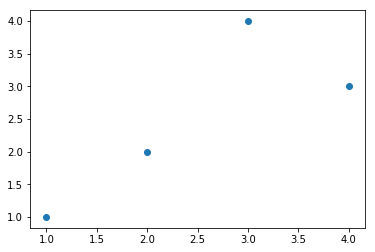

```python
fig, ax = plt.subplots()
ax.scatter(x, y)
```

Plots can also be combined together in the same axes. The line style and marker color can be changed to facilitate viewing the elements in th combined plot.

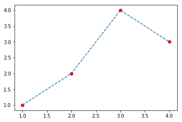

```python
fig, ax = plt.subplots()
ax.scatter(x, y, color='red')
ax.plot(x, y, linestyle='dashed')
```

And plot elements can be resized.

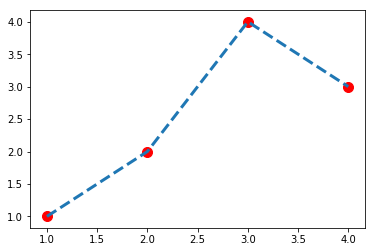

```python
fig, ax = plt.subplots()
ax.scatter(x, y, color='red', s=100)
ax.plot(x, y, linestyle='dashed', linewidth=3)
```

It is common to modify the plot after creating it, e.g. adding a title or label the axis.

```
Text(0.5,0,'Measurement X')
```

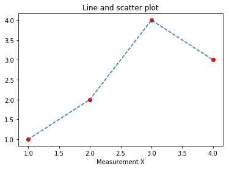

```python
fig, ax = plt.subplots()
ax.scatter(x, y, color='red')
ax.plot(x, y, linestyle='dashed')

ax.set_title('Line and scatter plot')
ax.set_xlabel('Measurement X')
```

The scatter and line plots can easily be separated into two subplots within the same figure, by telling `plt.subplots` to create a figure with one row and two columns (so two subplots side by side). This returns two axes objects, one for each subplot, which we assign to the variable names `ax1` and `ax2`.

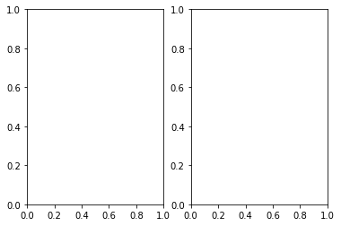

```python
fig, (ax1, ax2) = plt.subplots(1, 2)
# The default is (1, 1), that's why it does not need
# to be specified with only one subplot
```

To prevent plot elements, such as the axis tick labels from overlapping, `tight_layout()` method can be used.

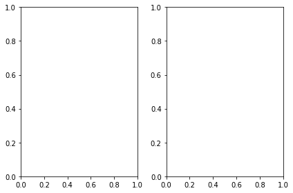

```python
fig, (ax1, ax2) = plt.subplots(1, 2)
fig.tight_layout()
```

The figure size can easily be controlled when it is created.

```python
# `figsize` refers to the size of the figure in inches when printed
fig, (ax1, ax2) = plt.subplots(1, 2, figsize=(8, 4))
fig.tight_layout()
```

[output not shown]

Bringing it all together to separate the line and scatter plot.

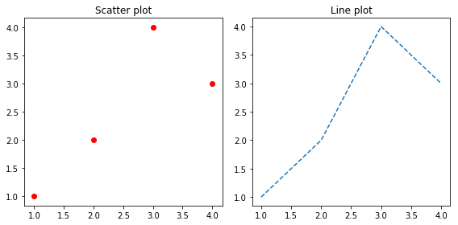

```python
fig, (ax1, ax2) = plt.subplots(1, 2, figsize=(8, 4))
ax1.scatter(x, y, color='red')
ax2.plot(x, y, linestyle='dashed')

ax1.set_title('Scatter plot')
ax2.set_title('Line plot')
fig.tight_layout()
```

#### Challenge 1

> 1. There is a plethora of colors available to use in `matplotlib`. Change the color of the line and the dots in the figure using [your favorite color from this list](https://stackoverflow.com/a/37232760/2166823).
> 2. Use the documentation to change the styling of the line in the line plot and the type of marker used in the scatter plot (you might need to search online to figure this out).

### Saving plots

Figures can be saved by calling the `savefig()` method and specifying the name of file to create. The resolution of the figure can be controlled by the `dpi` parameter.

```python
fig.savefig('scatter-and-line.png', dpi=300)
```

In the JupyterLab file browser, you can see that a new image file has been created. A PDF-file can be saved by changing the extension in the specified file name. Since PDF is a vector file format, it is not possible to specify a resolution.

```python
fig.savefig('scatter-and-line.pdf')
```

This concludes the customization section. The concepts taught here will be applied in the next section on how to choose a suitable plot type for data sets with many observations.

## Plotting dataframes

If the dataframe from the previous lecture is not loaded, read it in first.

```python
import pandas as pd

# world_data = pd.read_csv('../world-data-gapminder.csv')
# If not saved to disk yesterday
url = 'https://raw.githubusercontent.com/UofTCoders/2018-09-10-utoronto/gh-pages/data/world-data-gapminder.csv'
world_data = pd.read_csv(url)
```

We can use `scatter()` with the `data` parameter to plot columns from the dataframe.

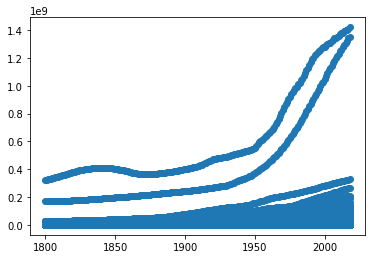

```python
fig, ax = plt.subplots()
ax.scatter(x='year', y='population', data=world_data)
```

The reason for the not immediately intuitive appearance of this graph, is that one scatter dot has been added for each year for every country. To instead see how the world's total population has changes over the years, the population from each country for each year needs to be summed together. This can be done using the dataframe techniques from the previous lecture.

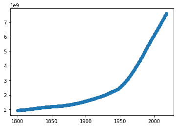

```python
# One could also do `as_index=False` with `groupby()`
world_pop = world_data.groupby('year')['population'].sum().reset_index()

fig, ax = plt.subplots()
ax.scatter(x='year', y='population', data=world_pop)
```

This plot shows that the world population has been steadily increasing since the 1800s and dramatically picked up pace in the 1950s.

It is possible to use `matplotlib` in this way to explore visual relationships in dataframe. However, it is a little cumbersome already with these simple examples and it will get more complicated once we want to include more variables, e.g. stratifying the data in subplots based on region and income level would include writing double loops and keeping track of plot layout and grouping variables manually. The Python package seaborn is designed for effectively exploring data visually without getting bogged down in technical plotting details.

## Visual data exploration with `seaborn`

When visually exploring data with lots of variables, it is in many cases easier to think in terms of what is to be explored in the data, rather than what graphical elements are to be added to the plot. For example, instead of instructing the computer to "go through a dataframe and plot any observations of country X in blue, any observations of country Y in red, etc", it is easier to just type "color the data by country". There are many benefits to using a so called *descriptive* syntax, instead of an *imperative* one.

Facilitating semantic mappings of data variable to graphical elements is one of the goals of the seaborn plotting package. Thanks to its functional way of interfacing with data, only minimal changes are required if the underlying data change or to switch the type of plot used for the visualization. `seaborn` provides a language that facilitates thinking about data in ways that are conducive for exploratory data analysis and allows for the creation of publication quality plots with minimal adjustments and tweaking.

The seaborn syntax was introduced briefly already in the introductory lecture and it is similar to how matplotlib plots dataframes. For example, to make the same scatter plot as above:

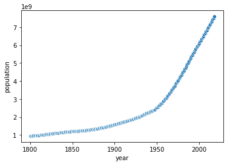

```python
import seaborn as sns

sns.scatterplot(x='year', y='population', data=world_pop)
```

In addition to providing a data-centric syntax, `seaborn` also facilitates visualization of common statistical aggregations. For example, the when creating a line plot in `seaborn`, the default is to aggregate and average all observations with the same value on the x-axis, and to create a shaded region representing the 95% confidence interval for these observations.

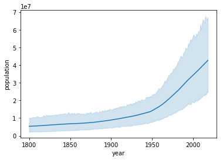

```python
sns.lineplot(x='year', y='population', data=world_data)
```

In this case, it would be more appropriate to have the shaded area describe the variation in the data, such as the standard deviation, rather than an inference about the reproducibility, such as the default 95% CI.

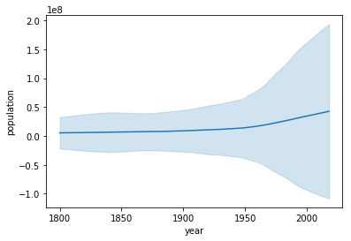

```python
sns.lineplot(x='year', y='population', data=world_data, ci='sd')
```

To change from showing the average world population per country and year to showing the total population for all countries per year, the `estimator` parameter can be used. Here, the shaded are is also removed with `ci=None`.

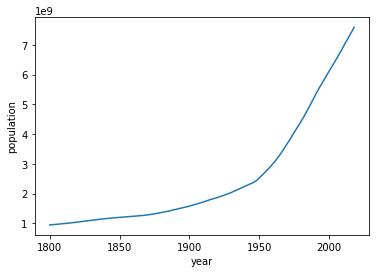

```python
# The `estimator` parameter is currently non-functional for sns.scatterplot, but will be added soon
sns.lineplot(x='year', y='population', data=world_data, estimator='sum', ci=None)
```

### Changing graph aesthetics

Before continuing the exploration of the world population data, let's discuss how to customize the appearance of our plots. The returned object is an matplotlib axes, so all configuration available through `matplotlib` can be applied to the returned object by first assigning it to a variable name (`ax` by convention).

```
Text(0.5,0,'Year')
```

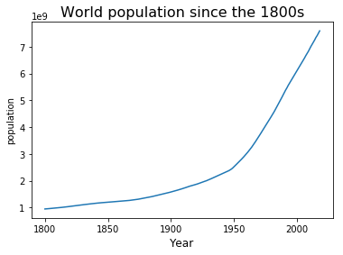

```python
ax = sns.lineplot(x='year', y='population', data=world_data, estimator='sum', ci=None)
ax.set_title('World population since the 1800s', fontsize=16)
ax.set_xlabel('Year', fontsize=12)
```

In addition to all the customization available through the standard `matplotlib` syntax, `seaborn` also offers its own functions for changing the appearance of the plots.

In essence, these functions are shortcuts to change several `matplotlib` parameters simultaneously For example, a more effective approach than setting individual font sizes or colors of graphical elements is to set the overall size and style for all graphs.

```python
sns.set(context='talk', style='darkgrid', palette='pastel')
sns.lineplot(x='year', y='population', data=world_data, estimator='sum', ci=None)
```

[output not shown]

These functions are analogues to making changes in the settings menu of a graphical program and they will apply to all following plots.

#### Challenge 2

> Find out which styles and contexts are available in seaborn. Try some of them out and choose your favorite style and context. *Hint* This information is available both through the built-in and the online documentation.

For the rest of this tutorial, the `ticks` style will be used.

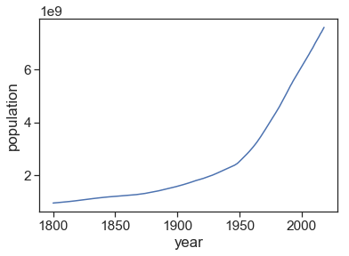

```python
sns.set(context='notebook', style='ticks', font_scale=1.4)
sns.lineplot(x='year', y='population', data=world_data, estimator='sum', ci=None)
```

For styles that include the frame around the plot, there is a special `seaborn` function to remove the top- and rightmost borders (again by modifying `matplotlib` parameters under the hood).

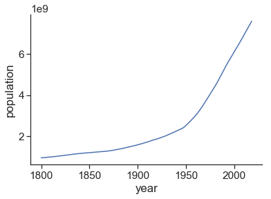

```python
sns.lineplot(x='year', y='population', data=world_data, estimator='sum', ci=None)
sns.despine()
```

If the style options exposed through `seaborn` are not sufficient, it is possible to change all plot parameters directly through the `matplotlib` [rc and style interfaces](https://matplotlib.org/users/customizing.html#customizing-matplotlib).

### Exploring relationships between two quantitative variables

As mentioned above, the main strength of a descriptive plotting syntax lies in describing the plot appearance in human-friendly vocabulary and have the computer assign variables to graphical objects accordingly. For example, to plot subsets of the data in different colors, the `hue` parameter can be used.

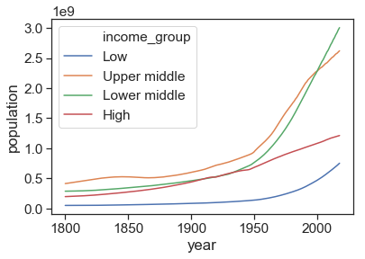

```python
sns.lineplot(x='year', y='population', hue='income_group',
            data=world_data, ci=None, estimator='sum')
```

This stratification of the income groups reveals that the population growth has been the fastest in middle income countries.

The plot can be made more accessible (especially to those with color vision deficiency) by changing the style of each line instead of only relying on color to separate them.

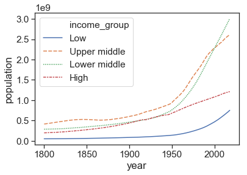

```python
sns.lineplot(x='year', y='population', hue='income_group', style='income_group',
            data=world_data, ci=None, estimator='sum')
```

Just like in the previous lecture, the values of the ordinal variable `income_group` are not listed in an intuitive order. A custom order can easily be specified by passing a list to the `hue_order` parameter, but this would have to be done for every plot. A more effective approach is to encode the order in the dataframe itself, using the top level `pandas` function `Categorical()`.

```python
world_data['income_group'] = (
    pd.Categorical(world_data['income_group'], ordered=True,
                   categories=['Low', 'Lower middle', 'Upper middle', 'High'])
)
world_data['income_group'].dtype
```

```
CategoricalDtype(categories=['Low', 'Lower middle', 'Upper middle', 'High'], ordered=True)
```

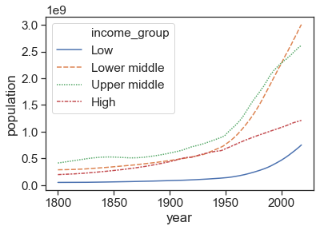

```python
sns.lineplot(x='year', y='population', hue='income_group', style='income_group',
             data=world_data, ci=None, estimator='sum')
```

The legend now lists the colors in the expected order. This modification also ensures that when making plots with income groups on the x- or y-axis, they will be plotted in the expected order.

### Conditioning quantitative relationships on qualitative variables

It is difficult to explore multiple categorical relationships within one single plot. For example, to see how the income groups compare within each region, the `hue` and `style` variables could be used for different variables, but this makes the plot dense and difficult to interpret.

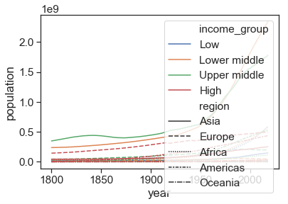

```python
sns.lineplot(x='year', y='population', hue='income_group', style='region',
            data=world_data, ci=None, estimator='sum')
```

An effective approach for exploring multiple categorical variables in a data set is to plot so-called "small multiples" of the data, where the same type of plot is used for different subsets of the data. These subplots are drawn in rows and columns forming a grid pattern, and can be referred to as a "facet", "lattice" or "trellis" plot.

Visualizing categorical variables in this manner is a key step in exploratory data analysis, and thus `seaborn` has a dedicated plot function for this, called `relplot()` (for "relational plot" since it visualizes the relationships between numerical variables). The syntax to `relplot()` is very similar to `lineplot()`, but we need to specify that the kind of plot we want is a line plot.

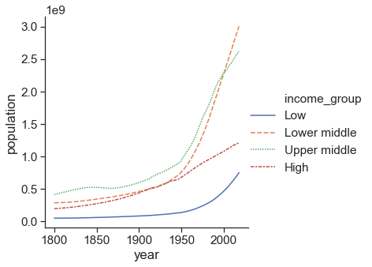

```python
# Create the same plot as above
sns.relplot(x='year', y='population', hue='income_group', style='income_group', kind='line',
            data=world_data, ci=None, estimator='sum')
```

The `region` variable can now be mapped to different facets/subplots in a grid pattern.

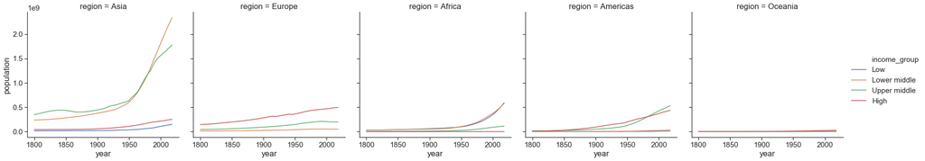

```python
# TODO switch this to some more interesting column if I have time
sns.relplot(x='year', y='population', data=world_data, estimator='sum',
            kind='line', hue='income_group', col='region', ci=None)
```

It's a little hard to see because the figure is very wide and has been shrunk to fit in the notebook. To avoid this, `relplot()` can use the `col_wrap` parameter to distribute the plots over several rows. The `height` and `aspect` parameters can be used to set the height and width of each facet.

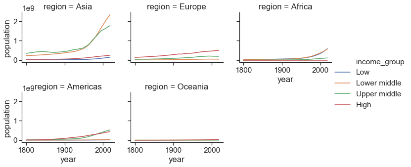

```python
sns.relplot(x='year', y='population', data=world_data, estimator='sum',
            kind='line', hue='income_group', col='region', ci=None,
           col_wrap=3, height=2.5, aspect=1.3)
```

Facetting the plot by region reveals that the largest absolute population increase occurred among middle income countries in Asia. We will soon look closer on which countries are.

The returned object from `relplot()` is a grid (a special kind of figure) with many axes, and can therefore not be placed within a preexisting figure. It is saved just as any `matplotlib` figure with `savefig()`, but has some special methods for easily changing the aesthetics of each axes.

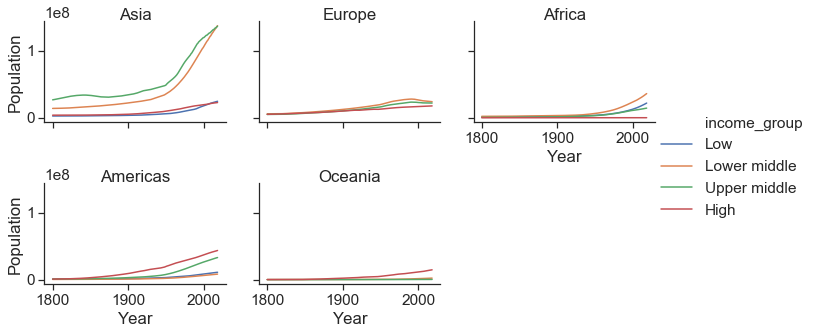

```python
g = sns.relplot(x='year', y='population', data=world_data,
            kind='line', hue='income_group', col='region', ci=None,
           col_wrap=3, height=2.5, aspect=1.3)

g.set_titles('{col_name}', y=0.95)
g.set_axis_labels(y_var='Population', x_var='Year')
g.savefig('grid-figure.png')
```

Remember that names such as `fig`, `ax`, and here `g`, are only by convention, and any variable name could have been used.

We might want the color to indicate income group, but draw separate lines for each country. For this we can set `units='country'` and `estimator=None` (so don't aggregate, just draw one line per country with the raw values).

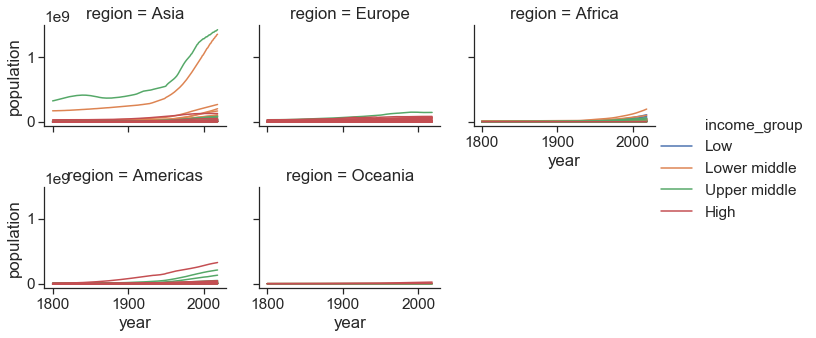

```python
sns.relplot(x='year', y='population', data=world_data, estimator=None, units='country',
            kind='line', hue='income_group', col='region', ci=None,
           col_wrap=3, height=2.5, aspect=1.3)
```

Two countries in Asia stand out in terms of total population. To find out which these are, we can filter the data.

```python
world_data.loc[world_data['year'] == 2018].nlargest(8, 'population')
```

|  | country | year | population | region | sub_region | income_group | life_expectancy | income | children_per_woman | child_mortality | pop_density | co2_per_capita | years_in_school_men | years_in_school_women |
| --- | --- | --- | --- | --- | --- | --- | --- | --- | --- | --- | --- | --- | --- | --- |
| 7226 | China | 2018 | 1420000000 | Asia | Eastern Asia | Upper middle | 76.9 | 16000 | 1.64 | 9.95 | 151.0 | NaN | NaN | NaN |
| 15767 | India | 2018 | 1350000000 | Asia | Southern Asia | Lower middle | 69.1 | 6890 | 2.28 | 41.10 | 455.0 | NaN | NaN | NaN |
| 37229 | United States | 2018 | 327000000 | Americas | Northern America | High | 79.1 | 54900 | 1.90 | 6.06 | 35.7 | NaN | NaN | NaN |
| 15986 | Indonesia | 2018 | 267000000 | Asia | South-eastern Asia | Lower middle | 72.0 | 11700 | 2.31 | 25.00 | 147.0 | NaN | NaN | NaN |
| 5036 | Brazil | 2018 | 211000000 | Americas | Latin America and the Caribbean | Upper middle | 75.7 | 14300 | 1.70 | 14.20 | 25.2 | NaN | NaN | NaN |
| 26498 | Pakistan | 2018 | 201000000 | Asia | Southern Asia | Lower middle | 68.0 | 5220 | 3.35 | 76.80 | 260.0 | NaN | NaN | NaN |
| 25622 | Nigeria | 2018 | 196000000 | Africa | Sub-Saharan Africa | Lower middle | 66.1 | 5570 | 5.39 | 97.90 | 215.0 | NaN | NaN | NaN |
| 2846 | Bangladesh | 2018 | 166000000 | Asia | Southern Asia | Lower middle | 73.4 | 3720 | 2.05 | 32.00 | 1280.0 | NaN | NaN | NaN |

> Challenge 3
> 1. To find out the total amount of CO2 released into the atmosphere, used the `co2_per_capita` and `population` columns to create a new column: `co2_total`.
> 2. Plot the total CO2 per year for the world.
> 3. Plot the total CO2 per year for the world and for each region.
> 4. Create a faceted plot comparing total CO2 levels across income groups and regions.

```python
# Challenge 3 solutions

# 1.
world_data['co2_total'] = world_data['co2_per_capita'] * world_data['population']

# 2.
sns.relplot(x='year', y='co2_total', data=world_data, kind='line', ci=None, estimator='sum')

# 3.
sns.relplot(x='year', y='co2_total', data=world_data, kind='line', ci=None, estimator='sum', hue='region')

# 4.
sns.relplot(x='year', y='co2_total', data=world_data, kind='line', ci=None, estimator='sum',
            hue='income_group', col='region', col_wrap=3, height=4)

# Discuss what these plots tell us:
# The world's total co2 emissions are rapidly increasing. Europe and the Americas have been the highest emitters for
# many years, but have recently been overtaken by Asia, which is now producing around twice the amount of co2 compare
# to Europe and America. But don't forget that we saw in the last lecture that the population in Asia is 5-6 times bigger
# than in Europe and America!

# It's important to look at both total production from a country because change within that single country has big
# potential of reaching many people. Not plotted here, but also also important is to explore which countries are high in CO2 per capita
# since these might have more room to reduce the production. Of course, reality is more complicated. Some countries
# might import goods that demand high CO2 production in their manufacturing country instead of producing themselves
# so they might "sponsor" the production in another country, but would not show up high in this list.
```

[output not shown]

To continue exploring the CO2 emissions we started to look at in the last challenge, let's use the other type of plot for comparing quantitative variables: `scatterplot()`. This is the default in the `relplot()` function, so we don't need to specify `kind='scatter'`)

As mentioned in the discussion above, in addition to considering the total amount of CO2 produced per country, it can be insightful to explore the CO2 produced per citizen.

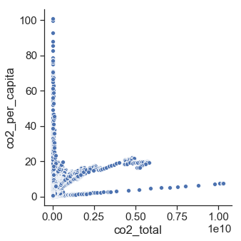

```python
sns.relplot(x='co2_total', y='co2_per_capita', data=world_data)
```

This looks funky, and not quite as expected... The reason is that we have plotted multiple data points per country, one for each year! This can be confusing since we don't know which dot is for which year and this plot is probably not what we wanted to create. Instead, we can filter the data to focus on a specific year. Unfortunately, there is not CO2 measurements available for the last few years. To find out in which years there are countries with CO2 measurements, we can drop the NAs in `co2_per_capita` and look at the min and max value.

```python
world_data.dropna(subset=['co2_per_capita'])['year'].agg(['min', 'max'])
```

```
min    1800
max    2014
Name: year, dtype: int64
```

Now we can subset the data for the latest available year with CO2 measurements, which is 2014.

```python
world_data_2014 = world_data.loc[world_data['year'] == 2014]
sns.relplot(x='co2_total', y='income', data=world_data_2014)
# TODO add to the line below significanlty what?
```

[output not shown]

Just as before, it is possible to map plot semantics and facet the plot according to variables in the data set. `scatterplot()` can also scale the dot size according to a variable in the data set.

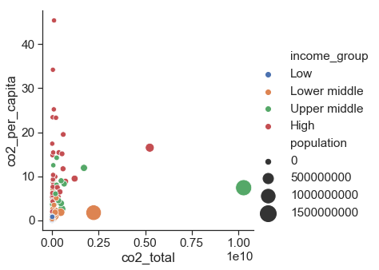

```python
# `sizes` controls the dots min and max size
sns.relplot(x='co2_total', y='co2_per_capita', hue='income_group', size='population',
            data=world_data_2014, sizes=(40, 400))
```

Unsurprisingly, some of the countries that are high in the total co2_emissions are also the most populous countries. The trends between different regions can now be easily compared by facetting the data by region.

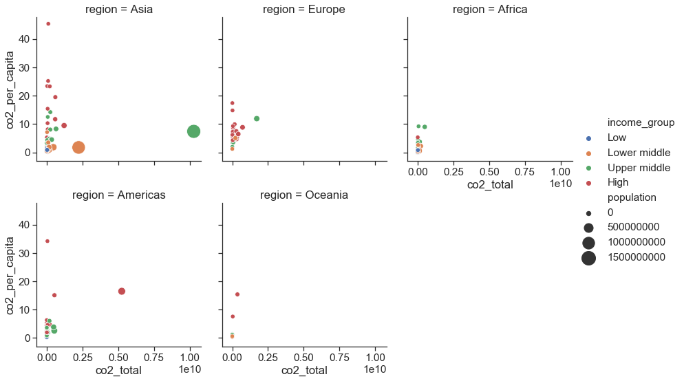

```python
sns.relplot(x='co2_total', y='co2_per_capita', hue='income_group', size='population',
            data=world_data_2014, sizes=(40, 400), col='region', col_wrap=3, height=4)
```

Already here we can get a pretty good idea of which some of these countries are. The high emission middle income countries in Asia are likely China and India, while the American country high in both total emissions and emissions per capita must be the USA. However, some observations are harder to resolve, like which the high co2_capita regions are in Asia and the Americas.

#### Challenge 4

> Let's use some of the aggregation methods from yesterday to complement the plots we have just made.
> 1. Find out which are the 10 countries with the highest co2 emissions per capita.
> 2. Find out which are the 10 countries with the highest total co2 emissions.
> 3. Which 10 countries have produce the most CO2 in total since the 1800s?

```python
# Challenge 4 solutions

# 1.
world_data_2014.nlargest(10, 'co2_per_capita')

# 2.
world_data_2014.nlargest(10, 'co2_total')

# 3.
world_data.groupby('country')['co2_total'].sum().nlargest(10)
```

In addition to what we observed above, an interesting aspect to explore is how the relationship between per capita and total CO2 emissions has changed over time for different income groups. As we have seen before, this can be explored in a line graph, but if we instead subset certain years from the data and create a facet for each year, we can see the spread at each point in time

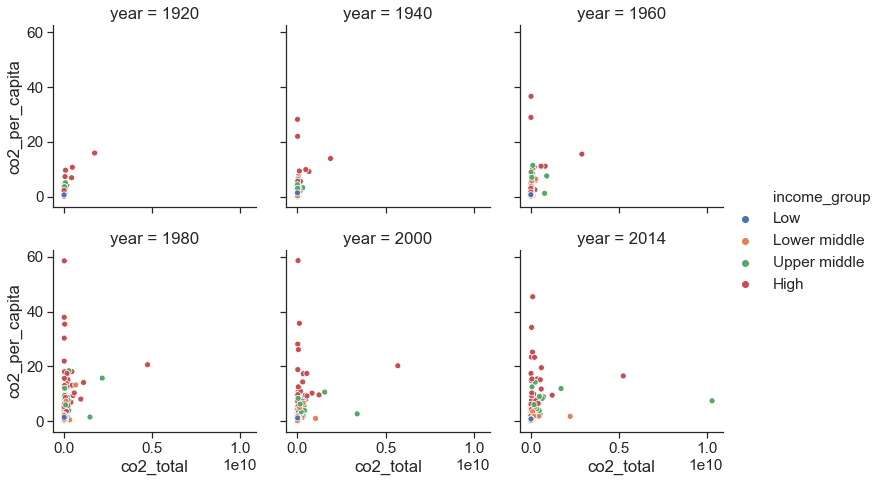

```python
world_data_1920_2018 = world_data.loc[world_data['year'].isin([1920, 1940, 1960, 1980, 2000, 2014])]

sns.relplot(x='co2_total', y='co2_per_capita', col='year', hue='income_group',
            data=world_data_1920_2018, col_wrap=3, height=3.5)
```

### How to know which relationships to start exploring?

In the exercises above, we chose suitable variables to illustrate the plotting concepts. Often when doing EDA, it will not be as easy to know what comparison to start with. Unless you have good reason to look at a particular relationship, starting by plotting the pairwise relationships of all quantitative variables can be helpful.

```python
# Use 2014 data since we know that there are CO2 measurements in that year
# This might take some time
sns.pairplot(world_data_2014)
```

[output not shown]

The year column is not that insightful since there is only one year in the data. Removing that column gives more space for the rest of the plots.

```python
sns.pairplot(world_data_2014.drop(columns='year'))
```

[output not shown]

Each histogram on the diagonal shows the distribution of a single variable in a histogram. The scatter plots below the diagonal show the relationship between two numerical variables in a scatter plot. The scatter plots above the diagonal are mirror images of those below the diagonal.

```python
world_data_2014.drop(columns='year').corr()
```

|  | population | life_expectancy | income | children_per_woman | child_mortality | pop_density | co2_per_capita | years_in_school_men | years_in_school_women | co2_total |
| --- | --- | --- | --- | --- | --- | --- | --- | --- | --- | --- |
| population | 1.000000 | 0.020899 | -0.039127 | -0.075136 | -0.012679 | 0.010329 | 0.009876 | -0.012609 | -0.055508 | 0.810722 |
| life_expectancy | 0.020899 | 1.000000 | 0.656187 | -0.799298 | -0.874404 | 0.177470 | 0.466554 | 0.726919 | 0.732383 | 0.117341 |
| income | -0.039127 | 0.656187 | 1.000000 | -0.530189 | -0.550647 | 0.277383 | 0.807494 | 0.581746 | 0.582572 | 0.097359 |
| children_per_woman | -0.075136 | -0.799298 | -0.530189 | 1.000000 | 0.876623 | -0.144019 | -0.430218 | -0.751975 | -0.784130 | -0.148606 |
| child_mortality | -0.012679 | -0.874404 | -0.550647 | 0.876623 | 1.000000 | -0.126336 | -0.442394 | -0.789018 | -0.818036 | -0.122293 |
| pop_density | 0.010329 | 0.177470 | 0.277383 | -0.144019 | -0.126336 | 1.000000 | 0.120080 | 0.084184 | 0.080018 | -0.010954 |
| co2_per_capita | 0.009876 | 0.466554 | 0.807494 | -0.430218 | -0.442394 | 0.120080 | 1.000000 | 0.441900 | 0.454274 | 0.159584 |
| years_in_school_men | -0.012609 | 0.726919 | 0.581746 | -0.751975 | -0.789018 | 0.084184 | 0.441900 | 1.000000 | 0.964648 | 0.122927 |
| years_in_school_women | -0.055508 | 0.732383 | 0.582572 | -0.784130 | -0.818036 | 0.080018 | 0.454274 | 0.964648 | 1.000000 | 0.088188 |
| co2_total | 0.810722 | 0.117341 | 0.097359 | -0.148606 | -0.122293 | -0.010954 | 0.159584 | 0.122927 | 0.088188 | 1.000000 |

With so much data, it is slow for us to process all the information as numbers in a table A higher bandwidth operation is to let our brain interpret colors for the strength of the relationships through a heatmap.

```python
sns.heatmap(world_data_2014.drop(columns='year').corr())
```

[output not shown]

The heatmap can be made more informative by changing to a diverging colormap, which is generally recommended when there is a natural central value (such as 0 in our case). Optionally, the heatmap can be annotated with the correlation coefficients.

```python
fig, ax = plt.subplots(figsize=(10, 6))
sns.heatmap(world_data_2014.drop(columns='year').corr(), annot=True, ax=ax, cmap='coolwarm')
```

[output not shown]

There are more formal ways of interrogating variable interactions and their potential causality (such as regressions), but these are outside the scope of this lecture. However, the pairwise scatter plot and correlation coefficient matrix are quick means to get an informative overview of how the dataframe columns relate to each other.

Let's zoom in on the relationship between income and life expectancy, which appears to be quite strong.

```python
# TODO Make this a challenge where they learn how to find things on stackoverflow
ax = sns.scatterplot(x='income', y='life_expectancy', data=world_data_2014)
```

[output not shown]

This relationship appears to be log linear and can be visualized with the x-axis set to log-scale.